# Univariate Distributions

MPA 634: Data Science for Managers

3 Feb 2020

## Prerequisites

The diamonds dataset

```r
data(diamonds)
summary(diamonds)
```

```
##      carat               cut        color        clarity          depth
##  Min.   :0.2000   Fair     : 1610   D: 6775   SI1    :13065   Min.   :43.00
##  1st Qu.:0.4000   Good     : 4906   E: 9797   VS2    :12258   1st Qu.:61.00
##  Median :0.7000   Very Good:12082   F: 9542   SI2    : 9194   Median :61.80
##  Mean   :0.7979   Premium  :13791   G:11292   VS1    : 8171   Mean   :61.75
##  3rd Qu.:1.0400   Ideal    :21551   H: 8304   VVS2   : 5066   3rd Qu.:62.50
##  Max.   :5.0100                     I: 5422   VVS1   : 3655   Max.   :79.00
##                                     J: 2808   (Other): 2531
##      table           price             x                y
##  Min.   :43.00   Min.   :  326   Min.   : 0.000   Min.   : 0.000
##  1st Qu.:56.00   1st Qu.:  950   1st Qu.: 4.710   1st Qu.: 4.720
##  Median :57.00   Median : 2401   Median : 5.700   Median : 5.710
##  Mean   :57.46   Mean   : 3933   Mean   : 5.731   Mean   : 5.735
##  3rd Qu.:59.00   3rd Qu.: 5324   3rd Qu.: 6.540   3rd Qu.: 6.540
##  Max.   :95.00   Max.   :18823   Max.   :10.740   Max.   :58.900
##
##        z
##  Min.   : 0.000
##  1st Qu.: 2.910
##  Median : 3.530
##  Mean   : 3.539
##  3rd Qu.: 4.040
##  Max.   :31.800
##
```

## Exploratory Data Analysis

1. Formulate questions about your data
2. Investigate answers to questions by visualizing, transforming, and modelling
3. Evolve and spawn new questions based on what is learned

Data cleaning also involves visualization, transformation, and modelling.

## Questions

“The key to asking quality questions is to generate a large quantity of questions.”

Two types of questions:

1. How is a variable distributed?
2. How are variables related to each other?

### Basic definitions

- Variable: quantity, quality, or property
- Value: state or level of a variable when it is measured
- Observation: “a set of measurements under similar conditions”
- Tabular data: “a set of values, each associated with a variable and an observation.”

## Distribution

- Possible values
- Frequency or probability of observing values

Describing the distribution gives us a basic set of questions to start asking. These in turn provoke additional questions. When considering a distribution, we should organize our preliminary investigation around:

1. Location or central tendency (mean and median)
2. Scale or spread (sd, range, and interquartile range)
3. Symmetry
4. Outliers

## Visualizing distributions of categorical variables

### Bar chart for cut using geom_bar

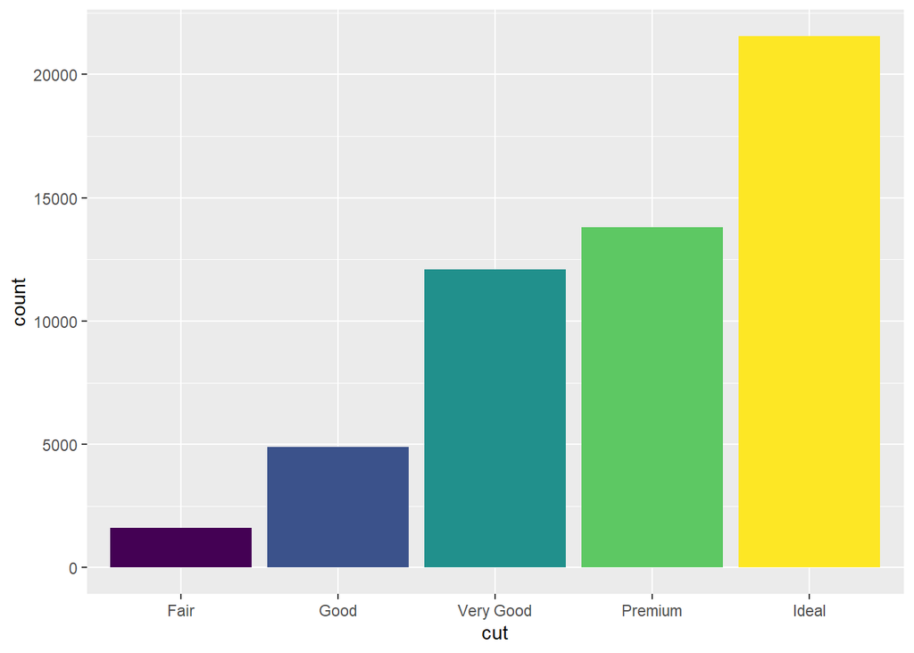

```r
diamonds %>%
  ggplot(aes(x = cut, fill = cut)) +
  geom_bar(show.legend = FALSE)
```

### Horizontal bar chart of cut using count and geom_col

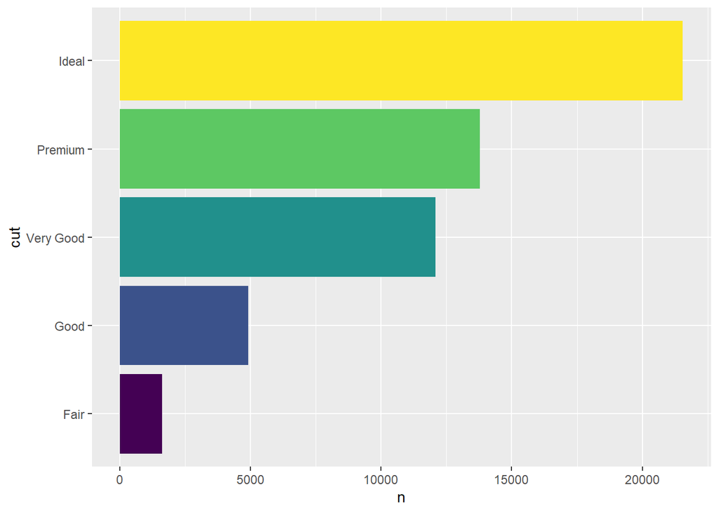

```r
diamonds %>%
  count(cut) %>%
  ggplot(aes(x = cut, y = n, fill = cut)) +
  geom_col(show.legend = FALSE) +
  coord_flip()
```

## Visualizing the distribution of a numerical variable

### Histogram of carat

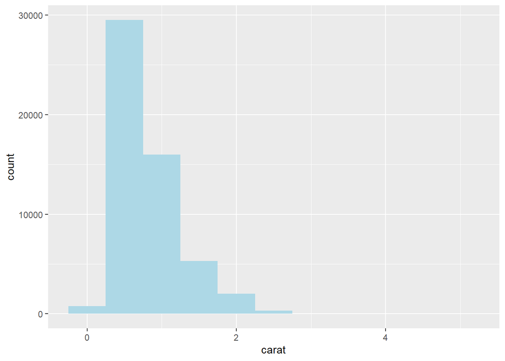

```r
diamonds %>%
  ggplot(aes(x = carat)) +
  geom_histogram(binwidth = 0.5, fill = "lightblue")
```

### Density of carat

We can control the amount of smoothing by using the bw argument to geom_density.

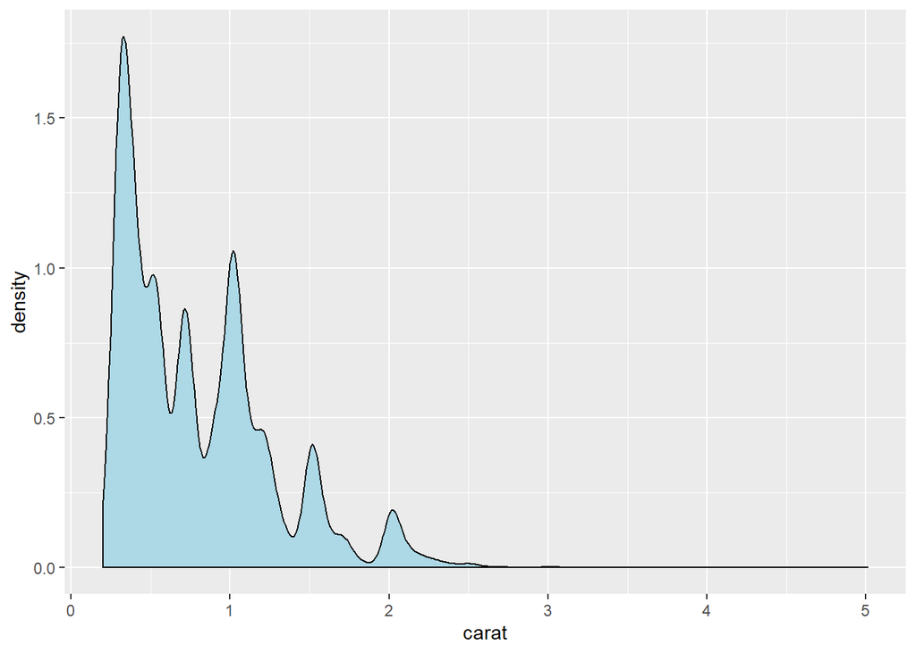

```r
diamonds %>%
  ggplot(aes(x = carat)) +
  geom_density(fill = "lightblue")
```

We can add tick marks for each observation by using the geom_rug. In order to keep the calculations to a reasonable level, we take a sample of 1,000 observations from the original diamonds data frame.

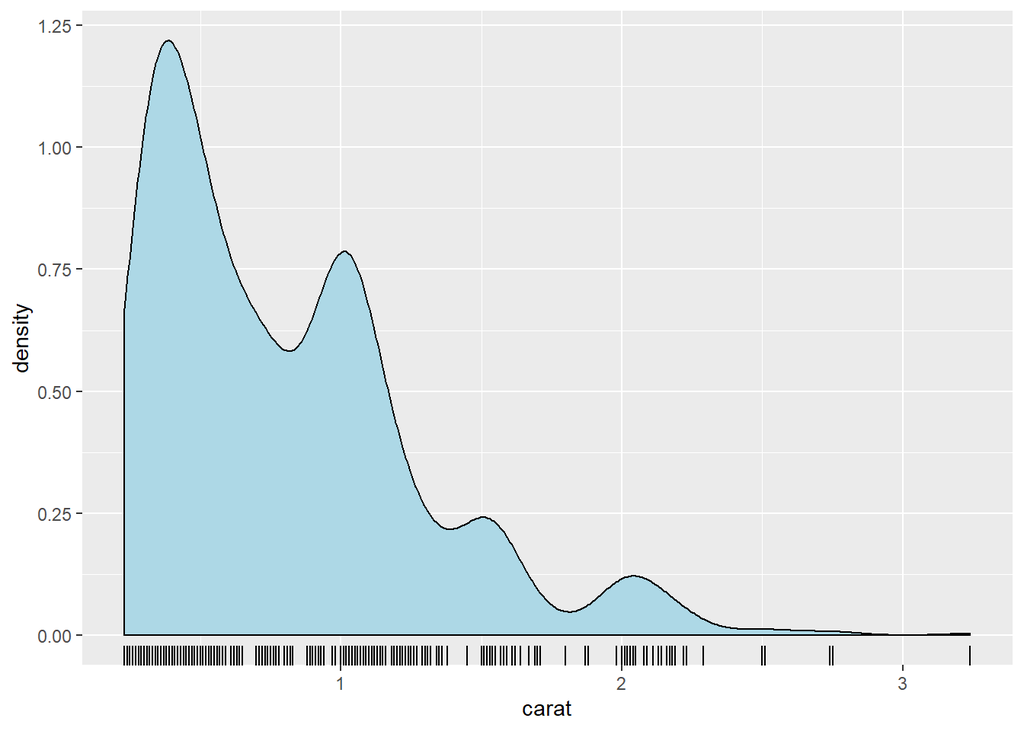

```r
diamonds %>%
  sample_n(1000) %>%
  ggplot(aes(x = carat)) +
  geom_density(fill = "lightblue") +
  geom_rug()
```

### Location or central tendency of the distribution is measured by the mean and the median

```r
mean(diamonds$carat)
```

```
## [1] 0.7979397
```

```r
median(diamonds$carat)
```

```
## [1] 0.7
```

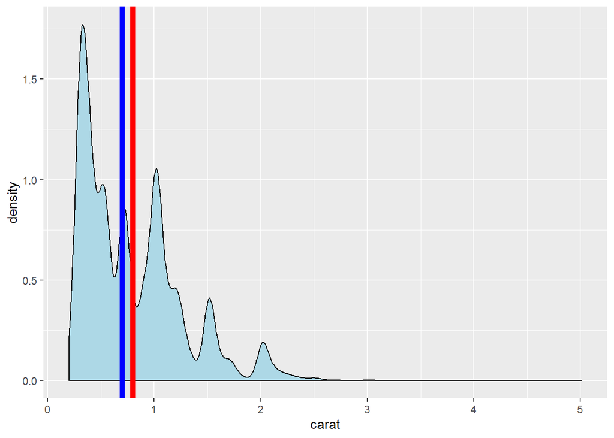

```r
diamonds %>%
  ggplot(aes(x = carat)) +
  geom_density(fill = "lightblue") +
  geom_vline(
    xintercept = mean(diamonds$carat),
    color = "red",
    size = 2
  ) +
  geom_vline(
    xintercept = median(diamonds$carat),
    color = "blue",
    size = 2
  )
```

### Scale or spread of carats as measured by standard deviation

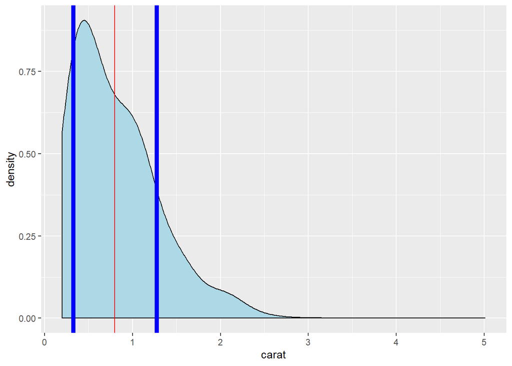

```r
carat_mean <- mean(diamonds$carat)
carat_sd <- sd(diamonds$carat)
diamonds %>%
  ggplot(aes(x = carat)) +
  geom_density(fill = "lightblue", bw = 0.2) +
  geom_vline(xintercept = carat_mean, color = "red") +
  geom_vline(xintercept = carat_mean - carat_sd, color = "blue", size = 2) +
  geom_vline(xintercept = carat_mean + carat_sd, color = "blue", size = 2)
```

### Quantiles of diamond size

The Tukey five number summary is the minimum, first quartile, median (second quartile), third quartile, and maximum. The quantile and summary functions give us these values.

```r
quantile(diamonds$carat)
```

```
##   0%  25%  50%  75% 100%
## 0.20 0.40 0.70 1.04 5.01
```

```r
summary(diamonds$carat)
```

```
##    Min. 1st Qu.  Median    Mean 3rd Qu.    Max.
##  0.2000  0.4000  0.7000  0.7979  1.0400  5.0100
```

### Boxplot of diamond size

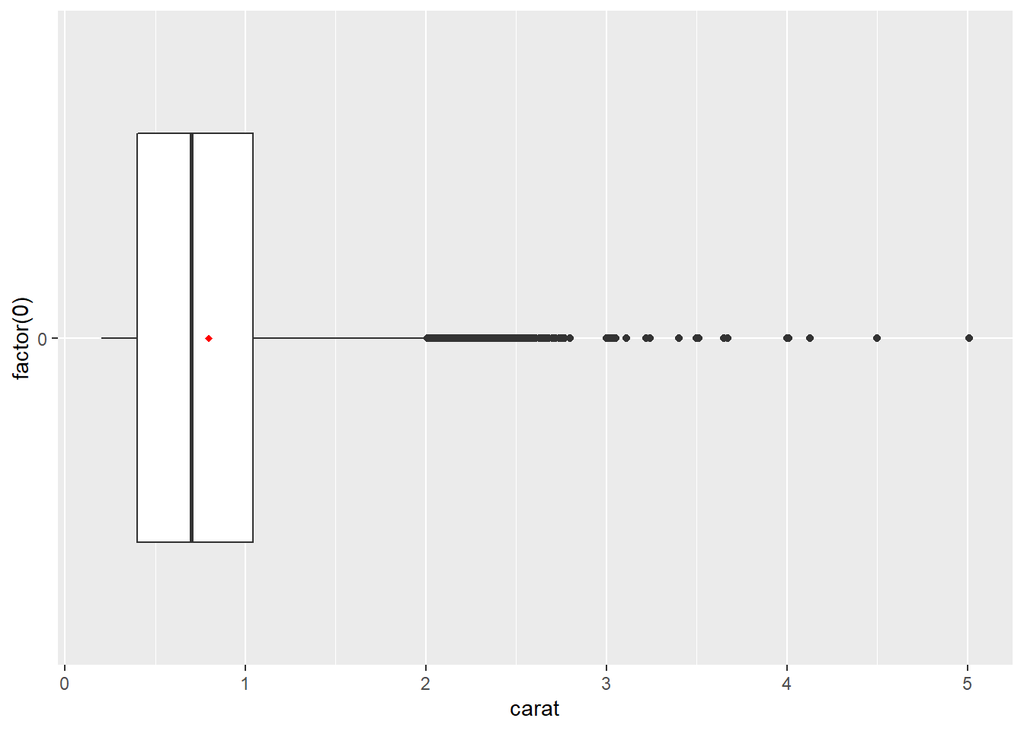

```r
diamonds %>%
  ggplot(aes(x = factor(0), y = carat)) +
  geom_boxplot() +
  stat_summary(fun.y = "mean",
             geom = "point",
             shape = 18,
             size = 1.5,
             color = "red") +
  coord_flip()
```

### Components of the box in the boxplot

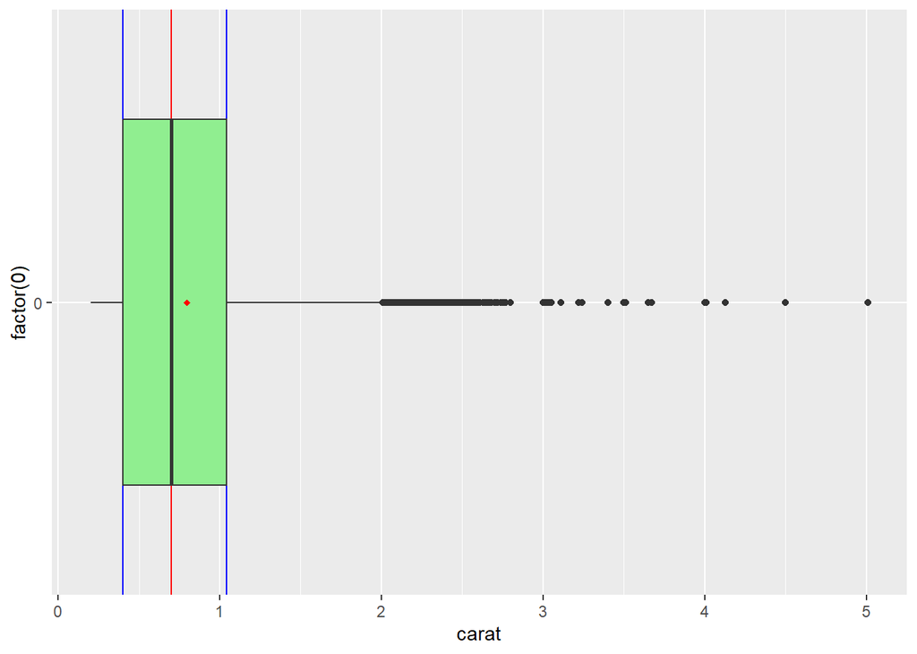

```r
Median <- median(diamonds$carat)
lower_hinge <- quantile(diamonds$carat, 0.25)
upper_hinge <- quantile(diamonds$carat, 0.75)

diamonds %>%
  ggplot(aes(x = factor(0), y = carat)) +
  geom_hline(yintercept = Median, color = "red") +
  geom_hline(yintercept = lower_hinge, color = "blue") +
  geom_hline(yintercept = upper_hinge, color = "blue") +
  geom_boxplot(fill = "lightgreen") +
  stat_summary(fun.y = "mean",
             geom = "point",
             shape = 18,
             size = 1.5,
             color = "red") +
  coord_flip()
```

### Interquartile range

The length of the box in the boxplot is called the interquartile range. It is the third quartile minus the first quartile.

```r
upper_hinge - lower_hinge
```

```
##  75%
## 0.64
```

```r
IQR(diamonds$carat)
```

```
## [1] 0.64
```

### Boxplot whiskers and outliers

The lower whisker of a boxplot starts at the lower hinge. We then move left 1.5 * IQR and then slide right towards the hinge until we encounter an observation.

The upper whisker of a boxplot starts at the upper hinge. We then move right 1.5 * IQR and then slide left towards the hinge until we encounter an observation.

Outliers are those observations that lie more than 1.5 * IQR from the lower and upper hinges.

Consider now the four dimensions of the diamond size distribution:

1. Location
2. Scale
3. Symmetry
4. Outliers

We determine symmetry by looking at the following:

1. Relationship of the mean and the median
2. Comparison of the left and right whiskers
3. Position of the median relative to the hinges of the box
4. Balance of left and right outliers

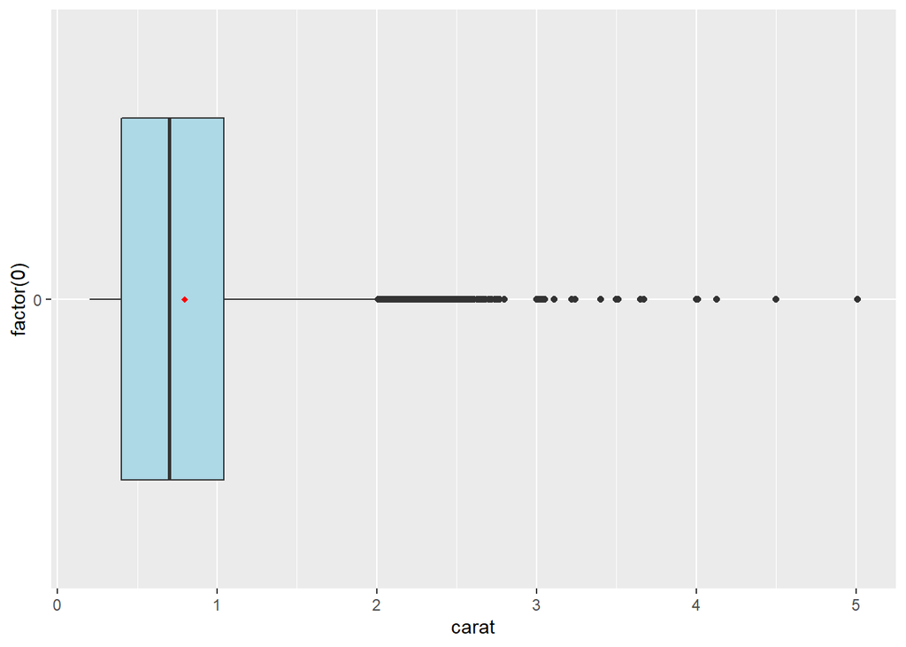

```r
diamonds %>%
  ggplot(aes(x = factor(0), y = carat)) +
  geom_boxplot(fill = "lightblue") +
  stat_summary(fun.y = "mean",
             geom = "point",
             shape = 18,
             size = 1.5,
             color = "red") +
  coord_flip()
```

### Now combine the density with the boxplot to get a violin plot

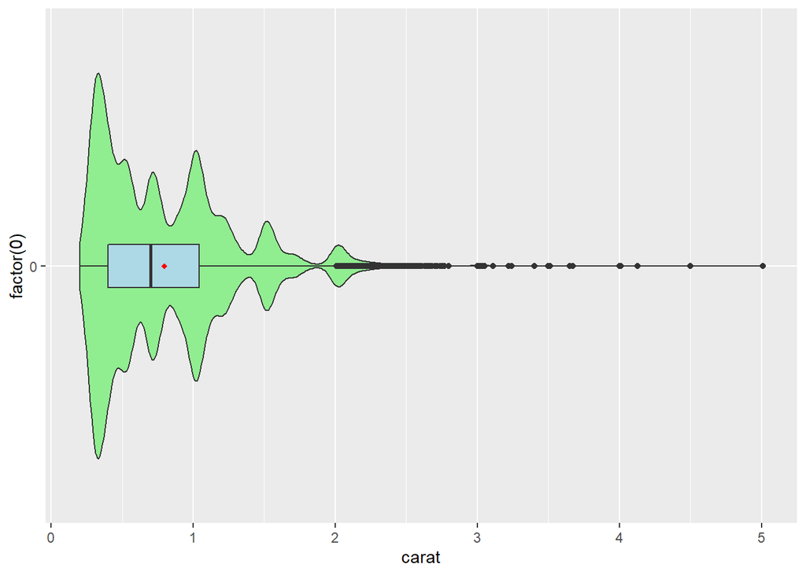

```r
diamonds %>%
  ggplot(aes(x = factor(0), y = carat)) +
  geom_violin(fill = "lightgreen") +
  geom_boxplot(fill = "lightblue", width = 0.1) +
  stat_summary(fun.y = "mean",
             geom = "point",
             shape = 18,
             size = 1.5,
             color = "red") +
  coord_flip()
```